# R Notebook

# 5 - Bar Charts

We have a number of different variables we can look at. Let’s make a bar chart to count how many elements there are of each type.

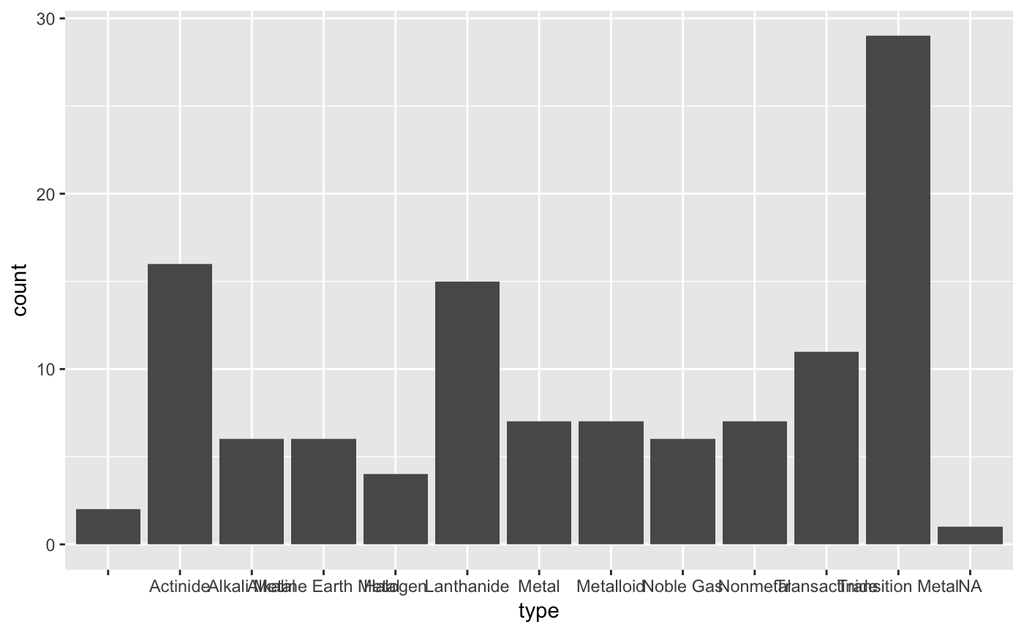

```r
ggplot(data=periodicTable) + geom_bar(mapping=aes(x=type))
```

You can pop out the graph into a separate window to de-smush the x-axis by clicking the small square icon (next to the arrows) in the top right of the graph window.

## Exercise 5.1 - Customizing Axes Text

Let’s add some axes titles and a chart title to our element type plot. We can add a layer of labels using the following: + labs(x = “X Axis Label”, y = “Y Axis Label”, title = “Plot Title”)

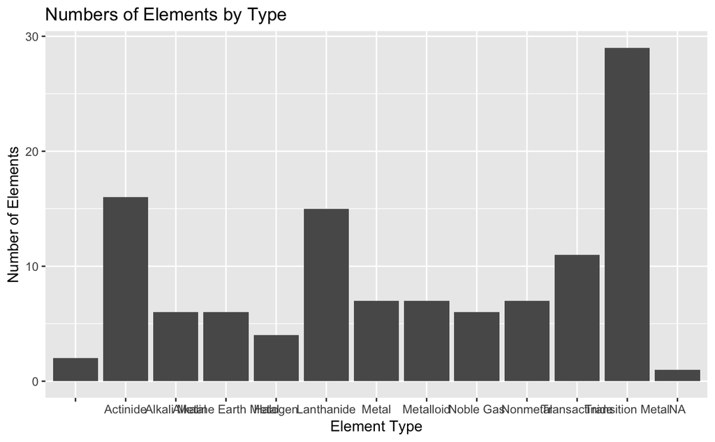

```r
ggplot(data=periodicTable) + geom_bar(mapping=aes(x=type)) + labs(x="Element Type", y="Number of Elements", title="Numbers of Elements by Type")
```

## Exercise 5.2 - Customizing Axes Position

What would make this plot look a little better?

We can rotate the X-axis label text using a theme() layer. The theme() layer is where all the non-content (i.e. non-data) elements of our graphs live. There are tons of options for themes (use help -> theme), and also many pre-defined themes.

Let’s replot our graph and make it a little easier to read. Add a new chunk by clicking the *Insert Chunk* button (top of the window on the toolbar) or by pressing *Cmd+Option+I*. To make our text a little easier to read, add the following layer to the graph:

- theme(axis.text.x=element_text(angle=90,hjust=1,vjust=0.5))

The ‘element_text’ command will change the ‘angle’, ‘hjust’ (horizontal justification/position) and ‘vjust’ (vertical justification/position) for the text of the X axis element (axis.text.x).

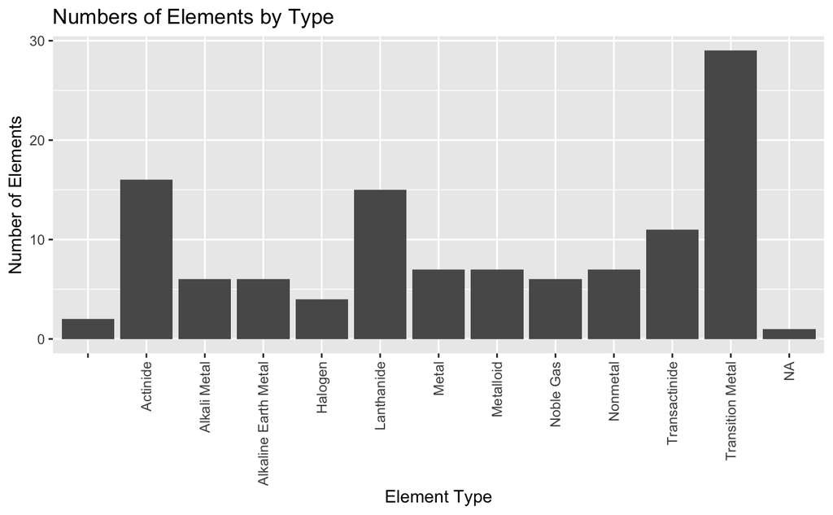

```r
ggplot(data=periodicTable) + geom_bar(mapping=aes(x=type)) + labs(x="Element Type", y="Number of Elements", title="Numbers of Elements by Type") + theme(axis.text.x=element_text(angle=90,hjust=1,vjust=0.5))
```

## Exercise 5.3 - Assigning a Plot to an Object for Reuse

Let’s say you want to experiment with a few different label types, but do not want to have to re-type the entire ggplot command every time you make your graph. At any point, with any number of layers, a ggplot can be assigned to an object, and that object can then be called and modified with further layers.

Run the following code chunk to assign our element type plot, without label modifications, to an object called et. The code will then display the et object.

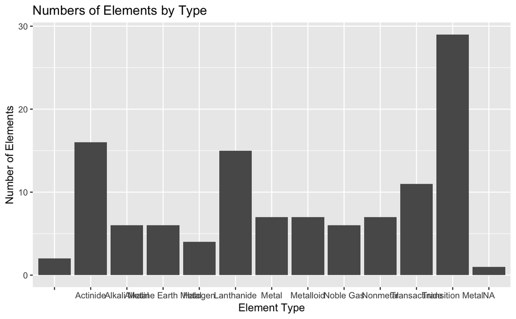

```r
et <- ggplot(data=periodicTable) + geom_bar(mapping=aes(x=type)) + labs(x="Element Type", y="Number of Elements", title="Numbers of Elements by Type")
et
```

You can see now that a new object, et, is available in the Global Environment, and you can inspect the additional plotting parameters that are stored in there. Why is this important? You may have a situation where you will be working with the same basic plot type over and over again - this gives you a programmatic way to modify aspects of the graph without retyping (or copy/pasting) the entire command. In general, for reproducible analysis, using objects is highly recommended.

Now, if we want to add a theme layer to our base et plot, we can simply run: et + theme()

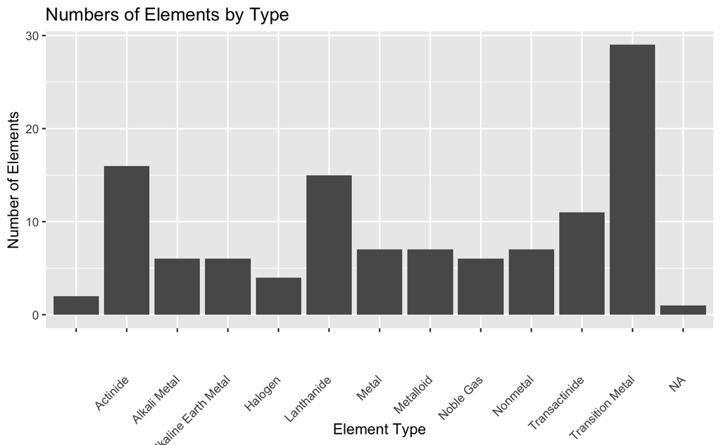

```r
et + theme(axis.text.x=element_text(angle=45,hjust=1,vjust=0.5))
```

Challenge: see if you can get the text to line up just below the X axis! What element of element_text do you need to change?

# Exercise 5.4 - How Many Phases?

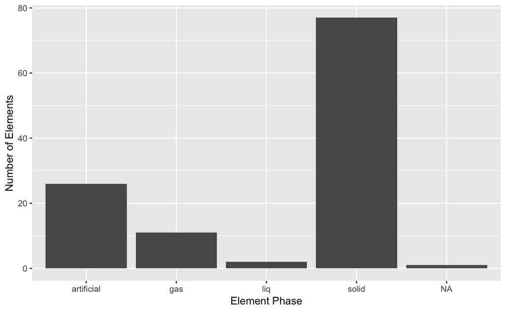

```r
ggplot(data=periodicTable) + geom_bar(mapping=aes(x=phase)) + xlab("Element Phase") + ylab("Number of Elements")
```

Can we get them to a point where they have a graph that is reproducible & reusable?

# 7 - Three-Dimensional Plots: Periodic Table Trends

We know that there are trends that we can see in the periodic table. This is an example of three-dimensional data. We have the two dimensions of the table - row and column - and our third dimension is the property that varies with them. Examples of this variance can be seen in ionic radius, electronegativity, etc.

Let’s make a plot of the periodic table that will show some of these trends. Run the code below to create a plot of the periodic table showing variance of electronegativiy with table position. The main layer creates the table, with X being the column and Y being the row. One type of 3D plot is geom_tile, and the aesthetic that we tell it to fill with is the Eneg (electronegativity) value (the “z” direction). So we should expect to see a color variance (what type of vector is Eneg?) with position in X and Y.

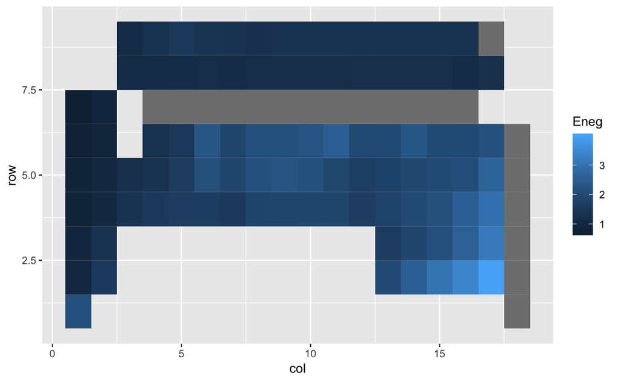

```r
ggplot(data=periodicTable,aes(x=col,y=row)) + geom_tile(aes(fill=Eneg))
```

So this looks close - what do we need to do to fix this?

Answers: flip the row axis, add axis marks for rows and columns.

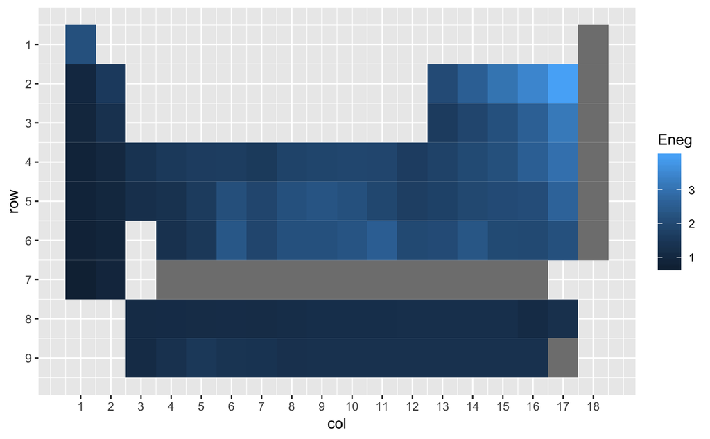

```r
ggplot(data=periodicTable,aes(x=col,y=row)) + geom_tile(aes(fill=Eneg)) + scale_y_reverse(breaks=seq(1,10,1)) + scale_x_continuous(breaks=c(1,2,3,4,5,6,7,8,9,10,11,12,13,14,15,16,17,18))
```

# Acknowledgements

Gail Clement, Head of Research Services, California Institute of Technology, for inspiration and assistance with proofreading and teaching.

Parts of this lesson are inspired by *Data Science in the tidyverse* by Charlotte Wickham, which is licensed under a Creative Commons Attribution 4.0 International License and based on a work at https://github.com/rstudio/master-the-tidyverse.

# References

1. More information can always be found in the help!
2. https://ggplot2.tidyverse.org/reference/
3. ggplot2: Elegant Graphics for Data Analysis, 2nd Ed., by Hadley Wickham. We are working on getting a print copy of this for the Library, but if you’d like to make your own PDF version from his GitHub repo, visit https://github.com/hadley/ggplot2-book
4. R for Data Science by Hadley Wickham, http://r4ds.had.co.nz/data-visualisation.html
5. https://groups.google.com/forum/#!forum/ggplot2
6. ggplot2 cheatsheet (2016): https://github.com/rstudio/cheatsheets/raw/master/data-visualization-2.1.pdf
7. https://www.computerworld.com/article/2935394/business-intelligence/my-ggplot2-cheat-sheet-search-by-task.html